# Course Project 1 for Reproducible Results

JA Butler

November 15, 2015

# Loading and preprocessing the data

Read in libraries to use

```r
library(dplyr)
```

```r
library(ggplot2)
library(knitr)
```

Read in the data file

```r
activity <- read.csv("activity.csv", header = TRUE)
```

Convert interval to a time of day

```r
activity$interval <- sprintf("%04d", activity$interval)
activity$tod <- format(strptime(activity$interval, format = "%H%M"), "%H:%M")
```

# Question 1: What is mean total number of steps taken per day?

Calculate total number of steps and graph the output. Include Mean and Median.

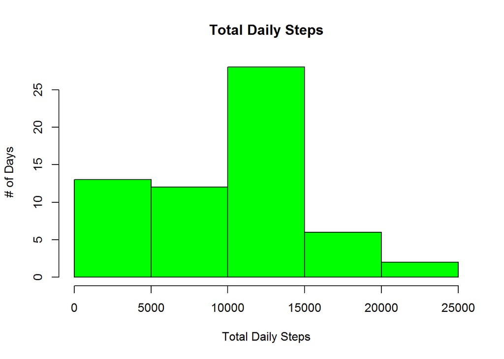

```r
dailysteps <- group_by(activity, date) %>% summarize(totsteps = sum(steps, na.rm = TRUE))
with(dailysteps, {
     hist(totsteps, xlab = "Total Daily Steps", ylab = "# of Days", col = "green",
          main = "Total Daily Steps")})
```

```r
print(paste("Average Daily Steps is ", mean(dailysteps$totsteps)))
```

```
## [1] "Average Daily Steps is  9354.22950819672"
```

```r
print(paste("Median Daily Steps is ", median(dailysteps$totsteps)))
```

```
## [1] "Median Daily Steps is  10395"
```

# Question 2: What is the average daily activity pattern?

Make a time series plot of the intervals through the day and also output highest mean step in an interval.

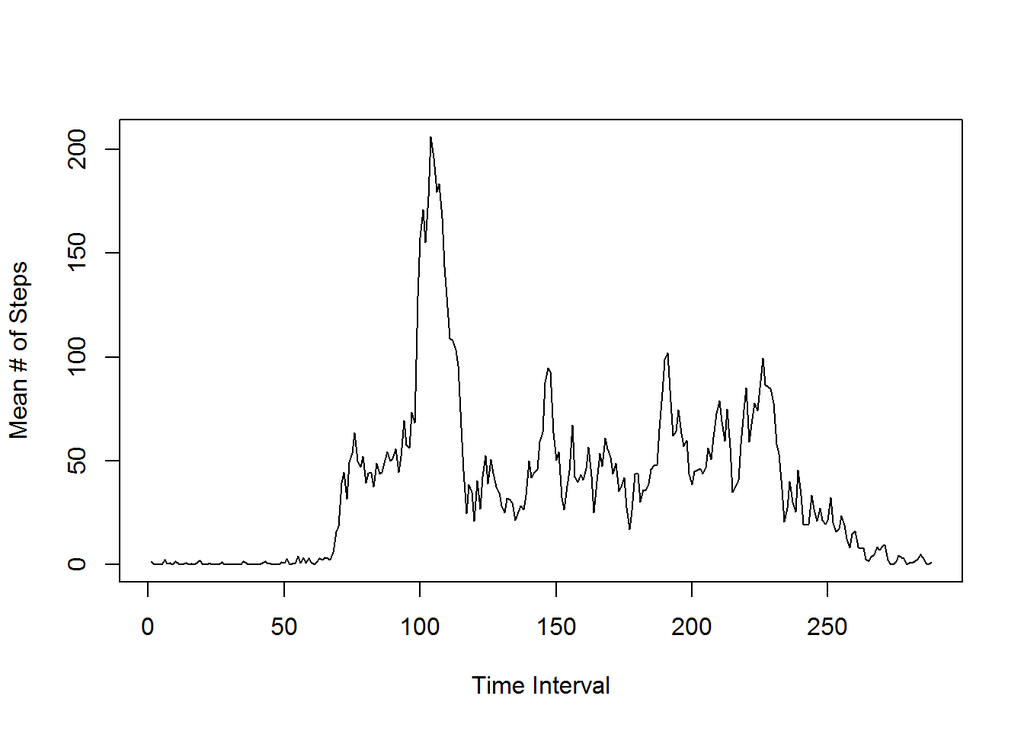

```r
activitypattern <- group_by(activity, tod) %>%
    summarize(intervalsteps = mean(steps, na.rm = TRUE))
with(activitypattern, {
     plot(intervalsteps, type = "l", xlab = "Time Interval", ylab = "Mean # of Steps")})
```

```r
maxactivity <- round(max(activitypattern$intervalsteps))
print(paste("Maximum average steps in a 5 minute interval is ", maxactivity))
```

```
## [1] "Maximum average steps in a 5 minute interval is  206"
```

# Imputing missing values

First create an indicator for the rows with missing values

```r
compind <- complete.cases(activity)
```

Second, create table to summarize the number of missing cases.

```r
table(compind)
```

```
## compind
## FALSE  TRUE
##  2304 15264
```

Third, add the missing data indicator to the data file.

```r
activity2 <- cbind(activity, compind)
```

Fourth, fill in missing values with mean for that interval using the interval mean and create new data set using the interval means to impute missing data.

```r
newactivity <- activity2 %>% merge(activitypattern, by.x = "tod") %>%
    mutate(steps = ifelse(is.na(steps)==TRUE, intervalsteps, steps)) %>%
    arrange(date, interval) %>% select(steps, date, interval)
```

Last, create a histogram of total step using the new data file and output mean and median to compare to original output.

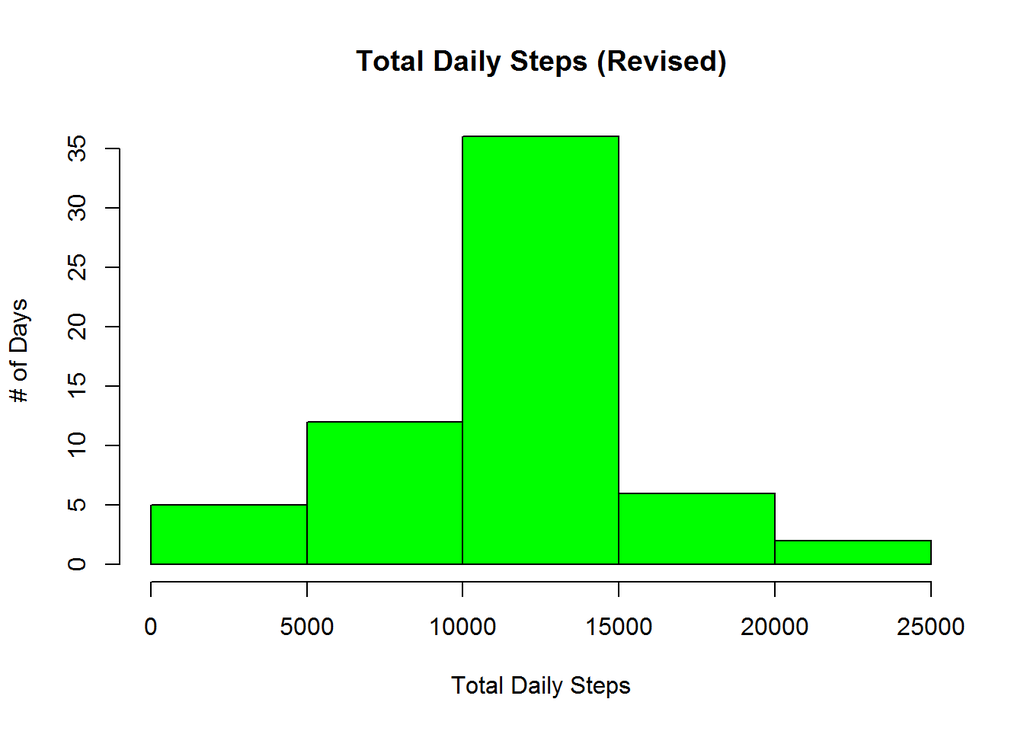

```r
dailysteps2 <- group_by(newactivity, date) %>% summarize(totsteps = sum(steps, na.rm = TRUE))
with(dailysteps2, {
    hist(totsteps, xlab = "Total Daily Steps", ylab = "# of Days", col = "green",
         main = "Total Daily Steps (Revised)")})
```

```r
print(paste("Revised Average Daily Steps is ", mean(dailysteps2$totsteps)))
```

```
## [1] "Revised Average Daily Steps is  10766.1886792453"
```

```r
print(paste("Revised Median Daily Steps is ", median(dailysteps2$totsteps)))
```

```
## [1] "Revised Median Daily Steps is  10766.1886792453"
```

# Question 3: are there differences in activity patterns b/t weekdays and weekends?

Create an indicator for weekday/weekend and use it to plot the average steps by interval.

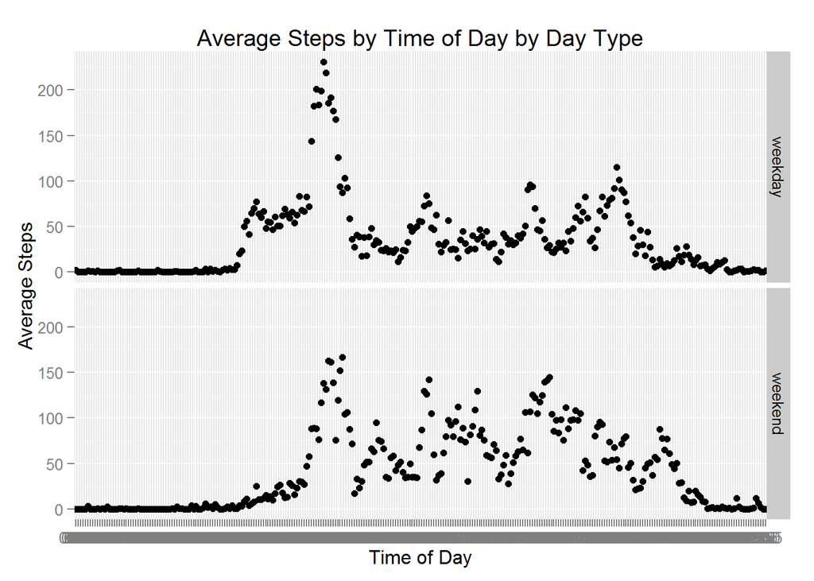

```r
newactivity$day <- weekdays(as.POSIXct(newactivity$date))
newactivity$daytype <- ifelse((newactivity$day=="Sunday" | newactivity$day =="Saturday"), "weekend", "weekday")

compactivity <- group_by(newactivity, daytype, interval) %>%
    summarize(avgstep = mean(steps))
qplot(interval, avgstep, data = compactivity, facets = daytype ~ .,
      xlab = "Time of Day", ylab = "Average Steps",
      main = "Average Steps by Time of Day by Day Type")
```